# Using LTA Soil Characteristics to Determine Potential Longleaf Pine Range

Author

Mollie Haremza and Randy Swaty

### Opportunity and Goals

In 2025 the US Department of Agriculture’s Forest Service (USFS) released updates to the [National Hierarchical Freamwork of Ecolgoical Units](https://www.fs.usda.gov/land/pubs/ecoregions/intro.html) delivered as The Ecomap 2025 dataset. The framework organizes the landscape into 5 smaller and smaller polygons that function similarly from an ecological perspective, based on shared physical and biological features. The stated purpose of this dataset is:

> to provide a baseline map of ecological boundaries. The data can be used for ecological analysis of resource distribution patterns and associations among different ecological land units. *From https://data-usfs.hub.arcgis.com/datasets/usfs::ecosys-ecomapsubsections-2025/about*

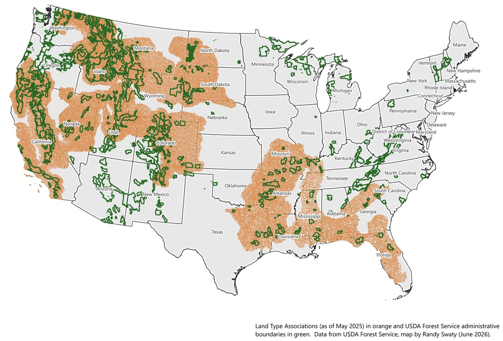

Land Type Associations and USFS adminsitrative boundaries as of May 2025.

The yet-to-be-released Land Type Associations (LTAs) are polygons in the 10s of thousands of acres, and have many descriptive attributes provided with the dataset including soil properties, landforms, and LANDFIRE’s [Existing Vegetation Types-Ecological Systems](https://landfire.gov/vegetation/evt). There are multiple examples of LTAs (developed by multiple organizations) in use that can be explored at this [Story Map](https://usfs.hub.arcgis.com/pages/a48f22ef8f3e4c5e9fcdbc53d4741cbe). When this dataset was shared with us there were ~67k polygons largely intersecting USFS administrative boundaries.

Inspired by conversations with [Dr. Sarah Anderson](https://www.linkedin.com/in/smanderson10/), we wanted to also explore the potential utility of LTAs. For this project we attempted to map out potential [longleaf pine (*Pinus palustris*)](https://en.wikipedia.org/wiki/Longleaf_pine) habitat using the soil properties attributed to LTAs. Additionally, we wanted to further develop our R and QGIS skills.

### Methods

Land Type Associations were clipped to the southeast region (AL, GA, FL, LA, MS) and research-grade Longleaf Pine observations were collected from [iNaturalist](https://www.inaturalist.org/). LTA’s were selected based on determined suitable soil characteristic ranges, such as depth to restriction, pH, organic material, bulk density, and % sand.

**Initial parameters:**

- Depth to restriction: > 6’
- pH: 4.99-5.51
- Organic material: 0.5-10.0
- Bulk density: 0.90-2.0 g/cm³
- Sand: > 60%

Parameters were then expanded by 10, 20, and 30% to include less suitable, yet possible regions.

### Results and Takeaways

Observations of Longleaf Pine are consistent with determined soil characteristics. This indicates that the average soil characteristics within a given land type association could potentially be used to predict the current or possiblel presence of a species within that LTA. Therefore, LTA characteristics could be used in conservation to make inferences about relatively inaccessible regions, such as the potential for Longleaf Pine presence.

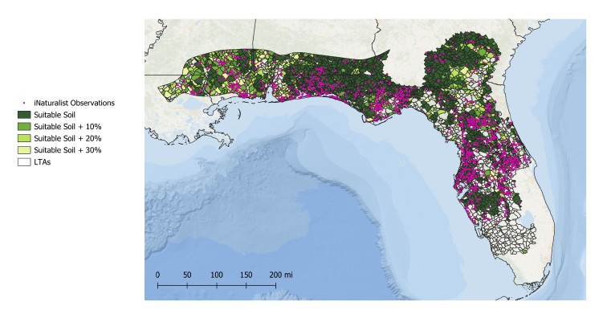

Longleaf Pine observations (magenta) and Suitable Soils (white (low) to dark green (high))